# Shiny

## Mise en pratique

- Ajoutez une phrase de bienvenue aléatoire depuis le `server`.

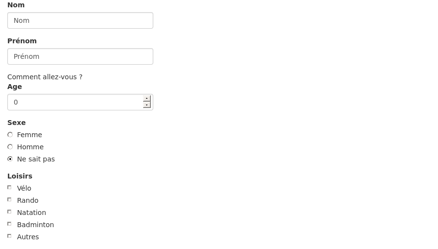

## Mise en pratique

- Créez une application affichant un graphique et son code.

```r
code_for_plot <- "plot(1:10)"

ui <- fluidPage(
  verbatimTextOutput("code"),
  plotOutput("plot")
)

server <- function(input, output, session) {
  output$code <- renderText({
    code_for_plot
  })
  output$plot <- renderPlot({
    eval(parse(text = code_for_plot))
  })
}
```

## Mise en pratique

- Créez une application affichant un graphique et son code.

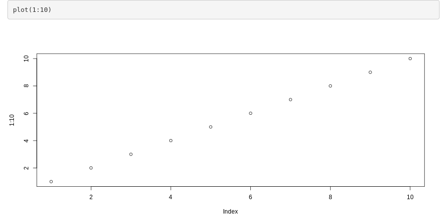

## *Shiny*

### La mise en page

## La mise en page “sidebar”

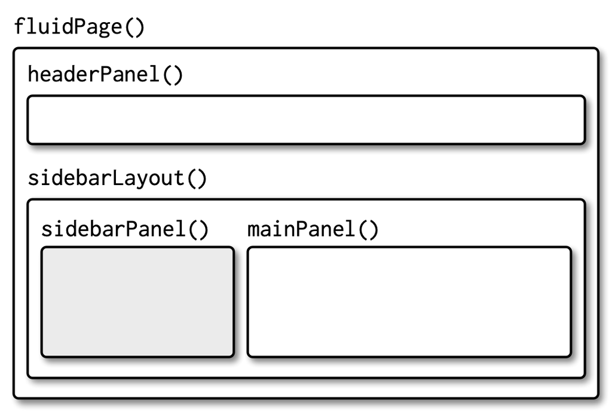

## La mise en page “sidebar” en code

```r
ui <- fluidPage(
  titlePanel("Un titre !"),
  sidebarLayout(
    sidebarPanel(
      sliderInput("point", "Point :", min = 0, max = 20, value = 5)
    ),
    mainPanel(
      plotOutput("plot", height = "500px")
    )
  )
)
```

## La mise en page “sidebar” en image

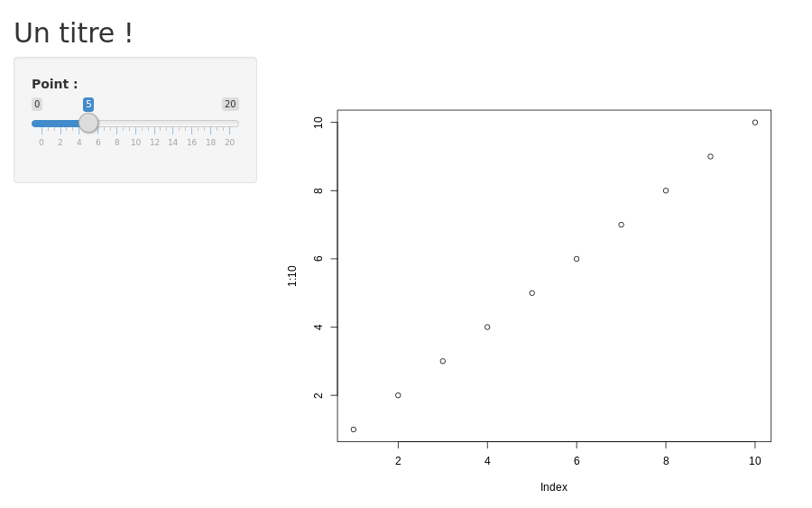

## La mise en page “multirow”

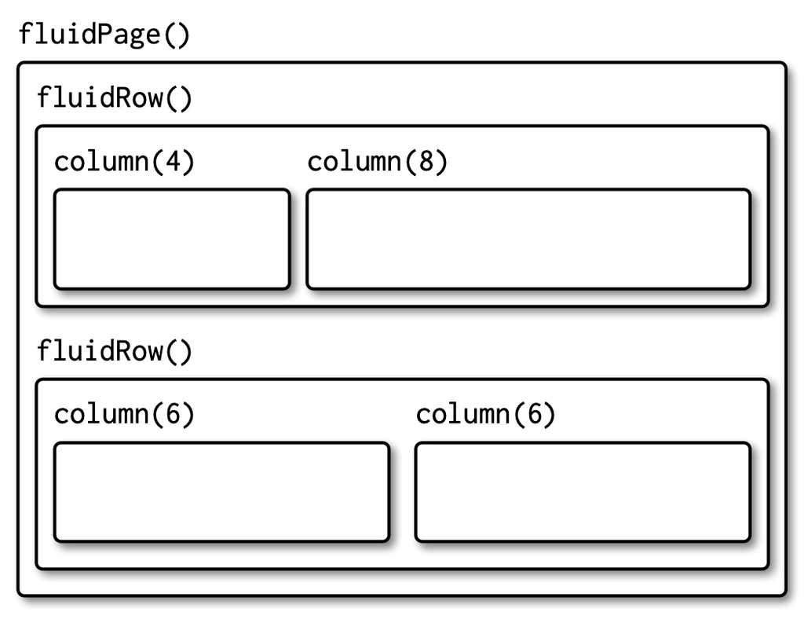

## La mise en page “multirow” en code

```r
ui <- fluidPage(
  fluidRow(
    column(width = 4,
      sliderInput("point", "Point :", min = 0, max = 20, value = 5)
    ),
    column(width = 8, plotOutput("plot"))
  ),
  fluidRow(
    column(width = 6,
      sliderInput("mean", "Moyenne :", min = 0, max = 2, value = 1)
    ),
    column(width = 6, plotOutput("plot2"))
  )
)
```

## La mise en page “multirow” en image

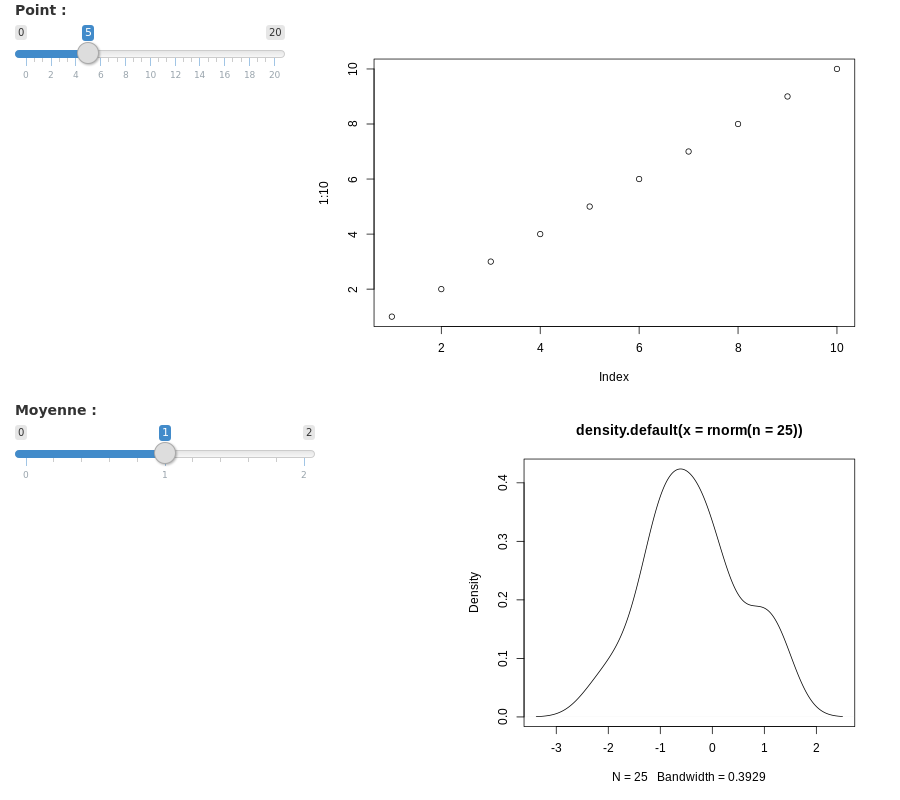

## La mise en page “tabset” en code

```r
ui <- navbarPage("App Title",
  tabPanel("Figures",
    tabsetPanel(
      tabPanel("point", plotOutput("plot")),
      tabPanel("Densité", plotOutput("plot2"))
    )
  ),
  tabPanel("Table", tableOutput("desc"))
)
```

## La mise en page “tabset” en image

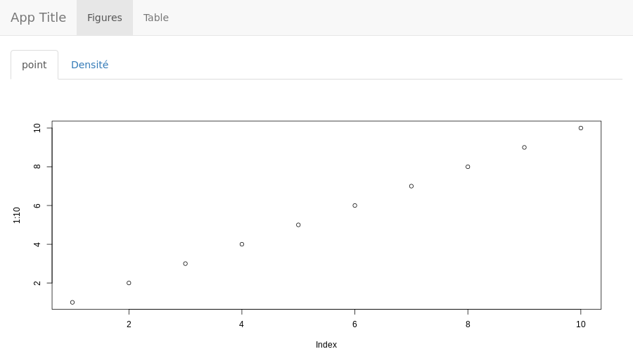

## La mise en page “dashboard” en code

```r
library("shinydashboard")

ui <- dashboardPage(
  dashboardHeader(),
  dashboardSidebar(),
  dashboardBody()
)
```

## La mise en page “dashboard” en image

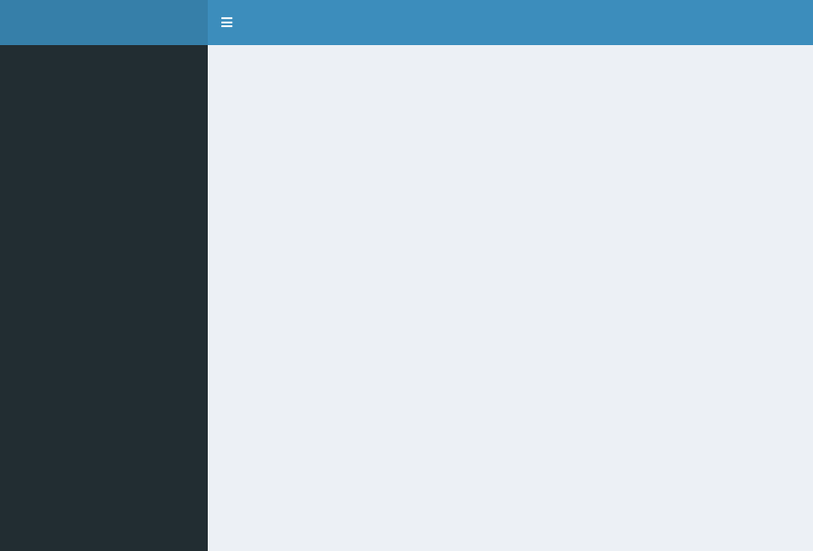

## La mise en page “dashboard” en code

```r
ui <- dashboardPage(
  dashboardHeader(title = "Shiny App"),
  dashboardSidebar(
    textInput("title", "Titre :", value = "Titre"),
    sliderInput("point", "Point :", min = 0, max = 20, value = 5),
    sliderInput("mean", "Moyenne :", min = 0, max = 2, value = 1)
  ),
  dashboardBody(
    fluidRow(
      box(plotOutput("plot"), width = 6),
      box(title = "Density", plotOutput("plot2"), width = 6)
    )
  )
)
```

## La mise en page “dashboard” en image

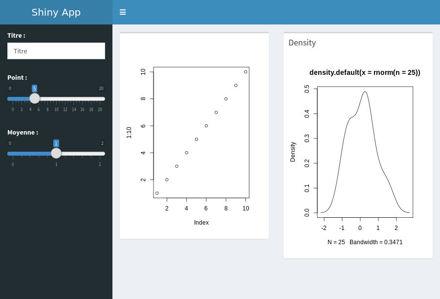

## Mise en pratique

- Essayez la structure grille avec `fluidPage()`, `fluidRow()`, `fixedRow()` et `column()`.
- Reproduisez les interfaces suivantes.

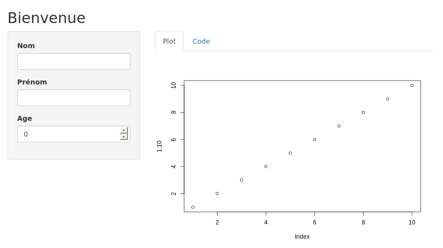

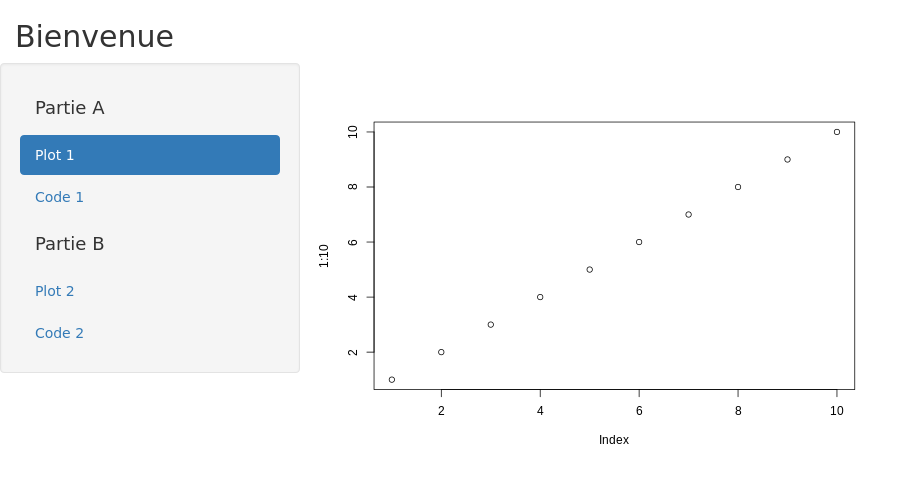

## Mise en pratique

- Reproduisez l’interface suivante.

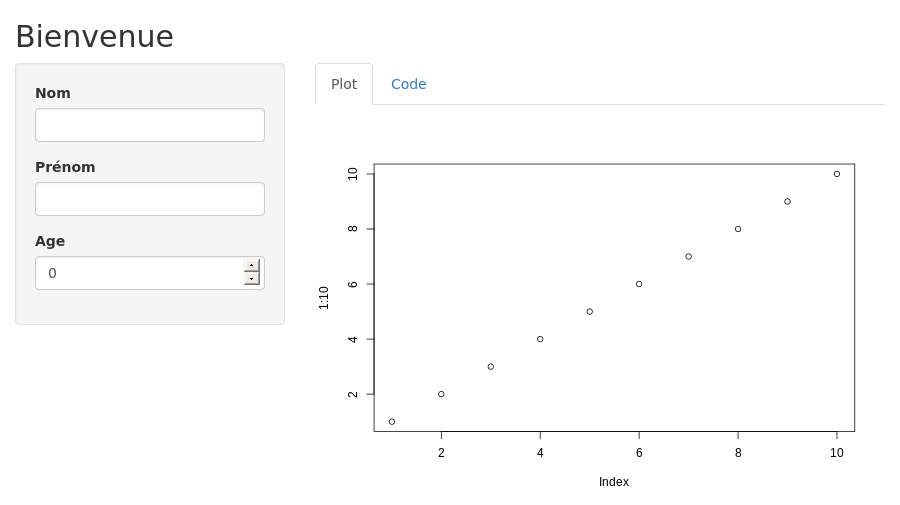

## Mise en pratique

- Reproduisez l’interface suivante.

```r
ui <- fluidPage(titlePanel("Bienvenue"),
  sidebarLayout(
    sidebarPanel(
      textInput("lastname", "Nom", value = ""),
      textInput("firstname", "Prénom", value = ""),
      numericInput("age", "Age", value = 0),
    ),
    mainPanel(
      tabsetPanel(
        tabPanel("Plot", plotOutput("plot")),
        tabPanel("Code", verbatimTextOutput("code"))
      )
    )
  )
)
```

## Mise en pratique

- Reproduisez l’interface suivante.

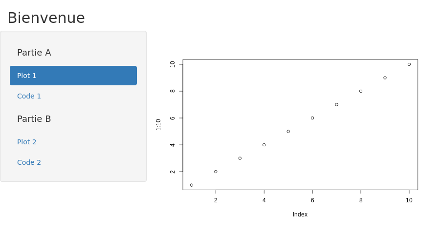

## Mise en pratique

- Reproduisez l’interface suivante.

```r
ui <- fluidPage(
  titlePanel("Bienvenue"),
  navlistPanel(
    "Partie A",
    tabPanel("Plot 1", plotOutput("plot1")),
    tabPanel("Code 1", verbatimTextOutput("code1")),
    "Partie B",
    tabPanel("Plot 2", plotOutput("plot2")),
    tabPanel("Code 2", verbatimTextOutput("code2"))
  )
)
```

## *Shiny*

### La face cachée `server`

## La fonction `server`

```r
server <- function(
  input,
  output,
  session
) {
  ...
}
```

- `input`, une liste de paramètres d’entrées.
- `output`, une liste d’objets à afficher dans `ui`.
- `session`, environnement relatif à la session,  
  *c.-à-d.*, la connection.

## La fonction `server`

- De `ui` au `server` \(\rightarrow\) `input`.

```r
ui <- fluidPage(
  textInput(
    inputId = "text",
    label =  "Texte : ", value = "Du texte par défaut ..."
  ),
  textOutput("text")
)
```

```r
server <- function(input, output, session) {
  output$text <- renderText({
    input$text
  })
}
```